# Explore PAHO Data: Dengue

Eugene Joh

September 19, 2018

## Exploratory Data Analysis

Exploratory data analysis (EDA) is a fundamental (but not glorified) process within in the “data science” pipeline. By conducting this step in a cognizant manner can help in understanding the structure of the data, plan effective data cleaning, and processing for the analysis portion of the workflow. A good starting point on EDA is this [R for Data Science chapter](http://r4ds.had.co.nz/exploratory-data-analysis.html). To aid the process of EDA, this **parameterized R markdown** file accepts a (relatively) “tidy” dataset and will return some high level descriptives that are core to understanding the dataset.

- Data Type of each Column
- Number of Missing Observations `NA`
- Number of Unique Values

This can be easily be done by running the `glimpse` function from the `dplyr` package, but this markdown will provide some visualization to aid the understanding of the data. This will become useful when larger datasets (millions of rows and/or hundreds of columns) need to undergo some type of EDA.

## Data Types

```r
check_data_types <- function(list_names, input) {
  map_df(input[[list_names]], typeof) %>%
    gather(key = "Variable", value = "Data_Type") %>%
    left_join(
      map_df(input[[list_names]],
             ~sum(is.na(.))) %>% gather(key = "Variable", value = "N_Missing"),
              by = "Variable") %>%
    left_join(
      map_df(input[[list_names]],
             ~length(unique(.))) %>% gather(key = "Variable", value = "N_Unique"),
              by = "Variable") %>%
    mutate(
      N_row = nrow(input[[list_names]]),
      Data_File = list_names,
      Variable = fct_inorder(Variable)
    )
  }

df_dat_type <- map_dfr(names(params$input_data), check_data_types, params$input_data)
```

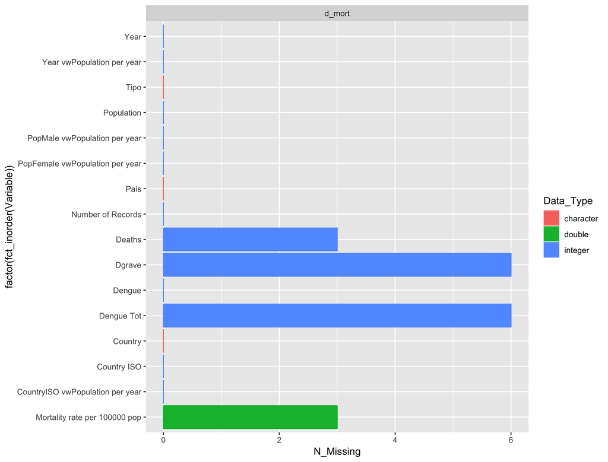

```r
df_dat_type %>%
  ggplot(aes(x = factor(fct_inorder(Variable)), y = N_Missing, fill = Data_Type, colour = Data_Type)) +
  geom_bar(stat='identity') +
  coord_flip() +
  facet_wrap(~Data_File, scales = "free")
```